# **apriori algorithm**

Xavier Vivancos García

2021-01-06

# 1 Preparación

Leemos e inspeccionamos los datos.

```r
# Load libraries
library(tidyverse)
library(arules)
library(arulesViz)
library(gridExtra)
library(knitr)
library(shiny)
library(shinythemes)

# Read the data
trans <- read.transactions("https://raw.githubusercontent.com/xavivg91/machine-learning/main/apriori/transactions.csv", format="single", cols=c(3,4), sep=",", rm.duplicates=TRUE)
```

## 1.1 Transaction object

```r
# Transaction object
trans
```

```
## transactions in sparse format with
##  6614 transactions (rows) and
##  104 items (columns)
```

## 1.2 Summary

```r
# Summary
summary(trans)
```

```
## transactions as itemMatrix in sparse format with
##  6614 rows (elements/itemsets/transactions) and
##  104 columns (items) and a density of 0.02008705
##
## most frequent items:
##  Coffee   Bread     Tea    Cake  Pastry (Other)
##    3188    2146     941     694     576    6272
##
## element (itemset/transaction) length distribution:
## sizes
##    1    2    3    4    5    6    7    8    9   10
## 2556 2154 1078  546  187   67   18    3    2    3
##
##    Min. 1st Qu.  Median    Mean 3rd Qu.    Max.
##   1.000   1.000   2.000   2.089   3.000  10.000
##
## includes extended item information - examples:
##                     labels
## 1               Adjustment
## 2 Afternoon with the baker
## 3                Alfajores
##
## includes extended transaction information - examples:
##   transactionID
## 1             1
## 2            10
## 3          1000
```

## 1.3 Glimpse

```r
# Glimpse
glimpse(trans)
```

```
## Formal class 'transactions' [package "arules"] with 3 slots
##   ..@ data       :Formal class 'ngCMatrix' [package "Matrix"] with 5 slots
##   ..@ itemInfo   :'data.frame':  104 obs. of  1 variable:
##   .. ..$ labels: chr [1:104] "Adjustment" "Afternoon with the baker" "Alfajores" "Argentina Night" ...
##   ..@ itemsetInfo:'data.frame':  6614 obs. of  1 variable:
##   .. ..$ transactionID: chr [1:6614] "1" "10" "1000" "1001" ...
```

## 1.4 Structure

```r
# Structure
str(trans)
```

```
## Formal class 'transactions' [package "arules"] with 3 slots
##   ..@ data       :Formal class 'ngCMatrix' [package "Matrix"] with 5 slots
##   .. .. ..@ i       : int [1:13817] 11 63 80 19 80 11 93 14 45 11 ...
##   .. .. ..@ p       : int [1:6615] 0 1 3 5 7 9 11 15 16 17 ...
##   .. .. ..@ Dim     : int [1:2] 104 6614
##   .. .. ..@ Dimnames:List of 2
##   .. .. .. ..$ : NULL
##   .. .. .. ..$ : NULL
##   .. .. ..@ factors : list()
##   ..@ itemInfo   :'data.frame':  104 obs. of  1 variable:
##   .. ..$ labels: chr [1:104] "Adjustment" "Afternoon with the baker" "Alfajores" "Argentina Night" ...
##   ..@ itemsetInfo:'data.frame':  6614 obs. of  1 variable:
##   .. ..$ transactionID: chr [1:6614] "1" "10" "1000" "1001" ...
```

# 2 Elección de soporte y confianza

¿Cuáles son los umbrales óptimos de soporte y confianza? Para valores bajos, el algoritmo tardará más en ejecutar y nos devolverá muchísimas reglas (la mayoría de ellas no nos servirán). Para valores muy altos, es probable que no obtengamos reglas. Probemos, pues, con diferentes valores de soporte y confianza, y veamos gráficamente cuántas reglas se generan para cada caso.

```r
# Support and confidence values
supportLevels <- c(0.1, 0.05, 0.01, 0.005)
confidenceLevels <- c(0.9, 0.8, 0.7, 0.6, 0.5, 0.4, 0.3, 0.2, 0.1)

# Empty integers
rules_sup10 <- numeric()
rules_sup5 <- numeric()
rules_sup1 <- numeric()
rules_sup0.5 <- numeric()

# Apriori algorithm with a support level of 10%
for (i in 1:length(confidenceLevels)) {

  rules_sup10[i] <- length(apriori(trans, parameter=list(sup=supportLevels[1],
                                   conf=confidenceLevels[i], target="rules")))

}

# Apriori algorithm with a support level of 5%
for (i in 1:length(confidenceLevels)){

  rules_sup5[i] <- length(apriori(trans, parameter=list(sup=supportLevels[2],
                                  conf=confidenceLevels[i], target="rules")))

}

# Apriori algorithm with a support level of 1%
for (i in 1:length(confidenceLevels)){

  rules_sup1[i] <- length(apriori(trans, parameter=list(sup=supportLevels[3],
                                  conf=confidenceLevels[i], target="rules")))

}

# Apriori algorithm with a support level of 0.5%
for (i in 1:length(confidenceLevels)){

  rules_sup0.5[i] <- length(apriori(trans, parameter=list(sup=supportLevels[4],
                                    conf=confidenceLevels[i], target="rules")))

}
```

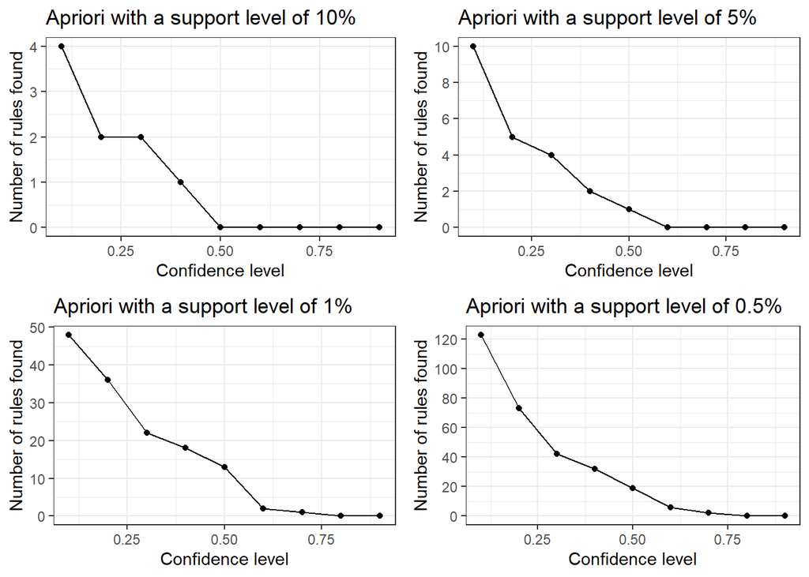

```r
# Number of rules found with a support level of 10%
plot1 <- qplot(confidenceLevels, rules_sup10, geom=c("point", "line"),
               xlab="Confidence level", ylab="Number of rules found",
               main="Apriori with a support level of 10%") +
  theme_bw()

# Number of rules found with a support level of 5%
plot2 <- qplot(confidenceLevels, rules_sup5, geom=c("point", "line"),
               xlab="Confidence level", ylab="Number of rules found",
               main="Apriori with a support level of 5%") +
  scale_y_continuous(breaks=seq(0, 10, 2)) +
  theme_bw()

# Number of rules found with a support level of 1%
plot3 <- qplot(confidenceLevels, rules_sup1, geom=c("point", "line"),
               xlab="Confidence level", ylab="Number of rules found",
               main="Apriori with a support level of 1%") +
  scale_y_continuous(breaks=seq(0, 50, 10)) +
  theme_bw()

# Number of rules found with a support level of 0.5%
plot4 <- qplot(confidenceLevels, rules_sup0.5, geom=c("point", "line"),
               xlab="Confidence level", ylab="Number of rules found",
               main="Apriori with a support level of 0.5%") +
  scale_y_continuous(breaks=seq(0, 130, 20)) +
  theme_bw()

# Subplot
grid.arrange(plot1, plot2, plot3, plot4, ncol=2)
```

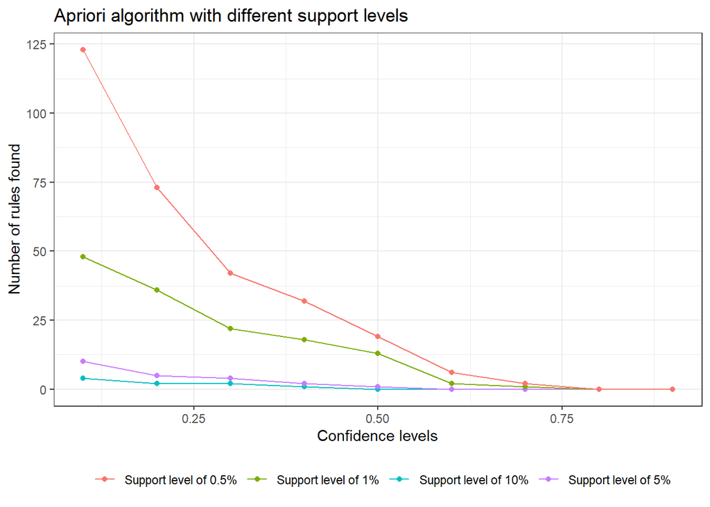

```r
# Data frame
num_rules <- data.frame(rules_sup10, rules_sup5, rules_sup1, rules_sup0.5, confidenceLevels)

# Number of rules found with a support level of 10%, 5%, 1% and 0.5%
ggplot(data=num_rules, aes(x=confidenceLevels)) +

  # Plot line and points (support level of 10%)
  geom_line(aes(y=rules_sup10, colour="Support level of 10%")) +
  geom_point(aes(y=rules_sup10, colour="Support level of 10%")) +

  # Plot line and points (support level of 5%)
  geom_line(aes(y=rules_sup5, colour="Support level of 5%")) +
  geom_point(aes(y=rules_sup5, colour="Support level of 5%")) +

  # Plot line and points (support level of 1%)
  geom_line(aes(y=rules_sup1, colour="Support level of 1%")) +
  geom_point(aes(y=rules_sup1, colour="Support level of 1%")) +

  # Plot line and points (support level of 0.5%)
  geom_line(aes(y=rules_sup0.5, colour="Support level of 0.5%")) +
  geom_point(aes(y=rules_sup0.5, colour="Support level of 0.5%")) +

  # Labs and theme
  labs(x="Confidence levels", y="Number of rules found",
       title="Apriori algorithm with different support levels") +
  theme_bw() +
  theme(legend.title=element_blank(),
        legend.position="bottom")
```

- **Soporte de 10%**. Sólo identificamos unas pocas reglas con valores de confianza muy bajos. Esto significa que no hay asociaciones frecuentes en nuestro data set.
- **Soporte de 5%**. Mismo problema, pocas reglas con valores de confianza bajos. Sólo identificamos una regla de como mínimo 50% de confianza.
- **Soporte de 1%**. Empezamos a obtener un mayor número de reglas, varias de ellas con mínimo 50% de confianza.
- **Soporte de 0.5%**. Demasiadas reglas que analizar.

# 3 Ejecución

```r
# Apriori algorithm execution with a support level of 1% and a confidence level of 50%
rules_sup1_conf50 <- apriori(trans, parameter=list(sup=supportLevels[3],
                             conf=confidenceLevels[5], target="rules"))
```

Las reglas obtenidas son las siguientes:

```r
# Inspect association rules
inspect(rules_sup1_conf50)
```

```
##      lhs                 rhs      support    confidence coverage   lift
## [1]  {Tiffin}         => {Coffee} 0.01058361 0.5468750  0.01935289 1.134577
## [2]  {Spanish Brunch} => {Coffee} 0.01406108 0.6326531  0.02222558 1.312537
## [3]  {Scone}          => {Coffee} 0.01844572 0.5422222  0.03401875 1.124924
## [4]  {Toast}          => {Coffee} 0.02570305 0.7296137  0.03522830 1.513697
## [5]  {Alfajores}      => {Coffee} 0.02237678 0.5522388  0.04052011 1.145705
## [6]  {Juice}          => {Coffee} 0.02131842 0.5300752  0.04021772 1.099723
## [7]  {Hot chocolate}  => {Coffee} 0.02721500 0.5263158  0.05170850 1.091924
## [8]  {Medialuna}      => {Coffee} 0.03296039 0.5751979  0.05730269 1.193337
## [9]  {Cookies}        => {Coffee} 0.02978530 0.5267380  0.05654672 1.092800
## [10] {NONE}           => {Coffee} 0.04172966 0.5810526  0.07181736 1.205484
## [11] {Sandwich}       => {Coffee} 0.04233444 0.5679513  0.07453886 1.178303
## [12] {Pastry}         => {Coffee} 0.04868461 0.5590278  0.08708800 1.159790
## [13] {Cake}           => {Coffee} 0.05654672 0.5389049  0.10492894 1.118042
##      count
## [1]   70
## [2]   93
## [3]  122
## [4]  170
## [5]  148
## [6]  141
## [7]  180
## [8]  218
## [9]  197
## [10] 276
## [11] 280
## [12] 322
## [13] 374
```

# 4 Resultados

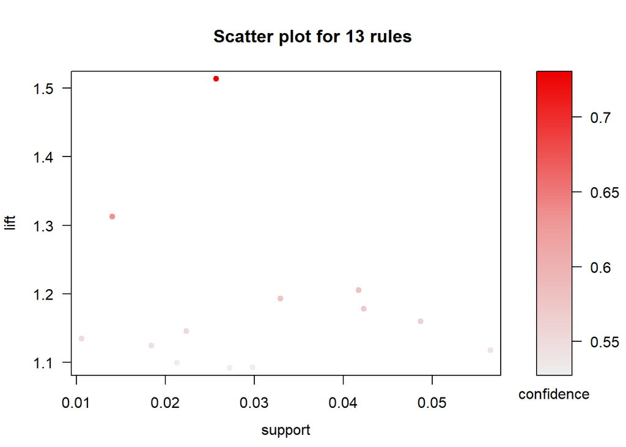

```r
# Scatter plot
plot(rules_sup1_conf50, measure=c("support", "lift"), shading="confidence")
```

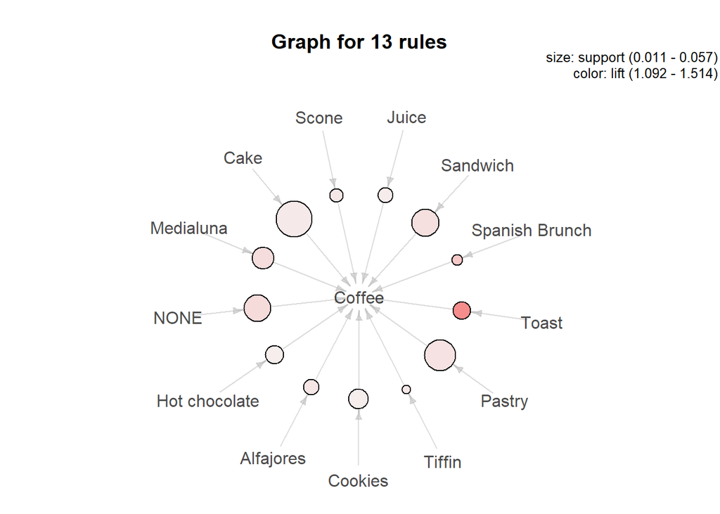

```r
# Graph (default layout)
plot(rules_sup1_conf50, method="graph")
```

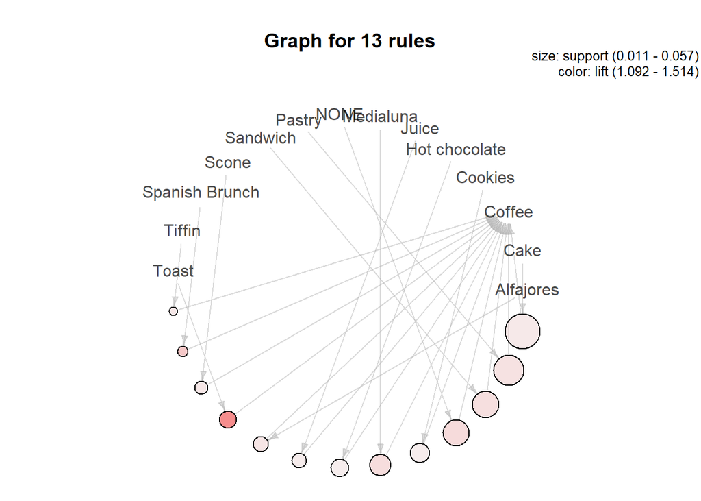

```r
# Graph (circular layout)
plot(rules_sup1_conf50, method="graph", control=list(layout=igraph::in_circle()))
```

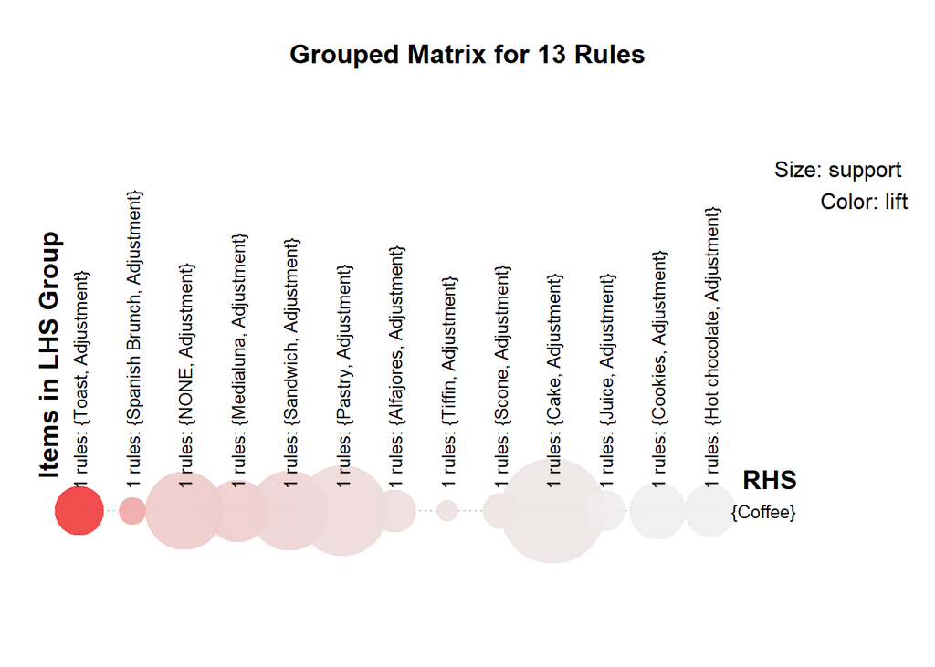

```r
# Grouped matrix plot
plot(rules_sup1_conf50, method="grouped")
```

Con la librería arulesViz podemos crear gráficos y tablas interactivas.

```r
# Apriori algorithm execution
rules <- apriori(trans, parameter=list(sup=supportLevels[4],
                             conf=confidenceLevels[9], target="rules"))

# Interactive tables
# inspectDT(rules)
# ruleExplorer(rules)
```